# Texas Covid-19 Predictions

Chance Robinson

8/9/2020

# Introduction

Time Series analysis for predicting the daily new COVID-19 case counts for Texas from 07/07/2020 to 08/07/2020.

# Library Imports

```r
library(plyr)
library(dplyr)
library(tidyverse)
# Date Manipulation
library(lubridate)
# Metrics
library(MLmetrics)
# Time Series Analysis
library(tseries)
library(forecast)
library(TSstudio)
```

# Load Data

## Training Set

```r
data <- read.csv("../../data/Corona_Curves_TX_NY_NJ.csv")

cols_to_keep <- c("State", "Date", "Daily_New_Cases", "Curve_Day", "Pop_Pct")

df_all <- data[cols_to_keep]

df_ny <- df_all %>%
  filter(State == 'NY')

df_nj <- df_all %>%
  filter(State == 'NJ')

df_tx <- df_all %>%
  filter(State == 'TX')

head(df_tx)
```

```
##   State      Date Daily_New_Cases Curve_Day   Pop_Pct
## 1    TX 6/19/2020            4497         1 0.0001504
## 2    TX 6/20/2020            4250         2 0.0001421
## 3    TX 6/21/2020            3125         3 0.0001045
## 4    TX 6/22/2020            5112         4 0.0001710
## 5    TX 6/23/2020            5370         5 0.0001796
## 6    TX 6/24/2020            6177         6 0.0002066
```

## Validation Set

```r
data2 <- read.csv("../../data/Corona_MAE.csv")


# rename the columns to match that of the original csv
test <- plyr::rename(data2, replace = c("TX.Date"="Date", "TX.New.Cases"="Daily_New_Cases"))

texas_population = 29900000

# create a new column that represents the Population Percentage
test <- test %>%
  mutate(Pop_Pct = Daily_New_Cases / texas_population, State = "TX")

# reorder the columns
test <- test[c("State", "Date", "Daily_New_Cases", "Curve_Day", "Pop_Pct")]

head(test)
```

```
##   State      Date Daily_New_Cases Curve_Day      Pop_Pct
## 1    TX  7/7/2020            9828        19 0.0003286957
## 2    TX  7/8/2020           10649        20 0.0003561538
## 3    TX  7/9/2020           11901        21 0.0003980268
## 4    TX 7/10/2020           10554        22 0.0003529766
## 5    TX 7/11/2020            8674        23 0.0002901003
## 6    TX 7/12/2020            6363        24 0.0002128094
```

# Exploratory Data Analysis

## New York Daily Case Counts

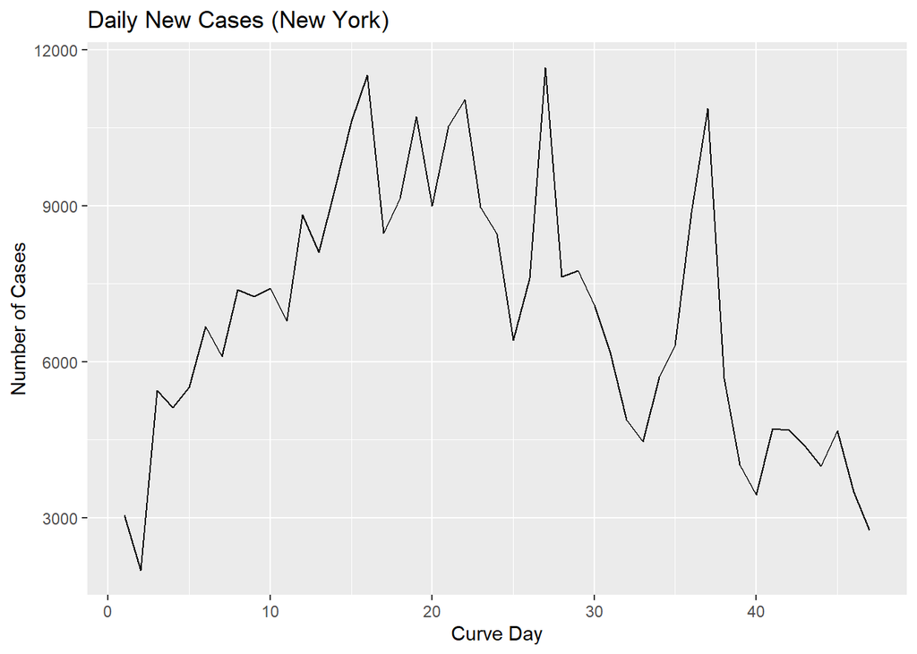

```r
ggplot(data=df_ny, aes(x = Curve_Day, y = Daily_New_Cases)) +
      geom_line() +
      ggtitle("Daily New Cases (New York)") +
      labs(x = "Curve Day", y = "Number of Cases")
```

```r
summary(df_ny)
```

```
##     State               Date           Daily_New_Cases   Curve_Day
##  Length:47          Length:47          Min.   : 1993   Min.   : 1.0
##  Class :character   Class :character   1st Qu.: 4794   1st Qu.:12.5
##  Mode  :character   Mode  :character   Median : 6785   Median :24.0
##                                        Mean   : 6909   Mean   :24.0
##                                        3rd Qu.: 8844   3rd Qu.:35.5
##                                        Max.   :11661   Max.   :47.0
##     Pop_Pct
##  Min.   :0.0001060
##  1st Qu.:0.0002549
##  Median :0.0003608
##  Mean   :0.0003674
##  3rd Qu.:0.0004703
##  Max.   :0.0006201
```

## New Jersey Daily Case Counts

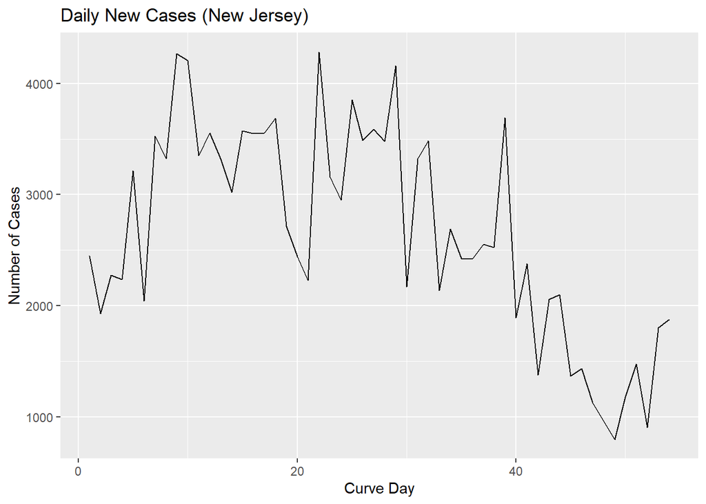

```r
ggplot(data=df_nj, aes(x = Curve_Day, y = Daily_New_Cases)) +
      geom_line() +
      ggtitle("Daily New Cases (New Jersey)") +
      labs(x = "Curve Day", y = "Number of Cases")
```

```r
summary(df_nj)
```

```
##     State               Date           Daily_New_Cases   Curve_Day
##  Length:54          Length:54          Min.   : 798    Min.   : 1.00
##  Class :character   Class :character   1st Qu.:2048    1st Qu.:14.25
##  Mode  :character   Mode  :character   Median :2538    Median :27.50
##                                        Mean   :2659    Mean   :27.50
##                                        3rd Qu.:3486    3rd Qu.:40.75
##                                        Max.   :4284    Max.   :54.00
##     Pop_Pct
##  Min.   :8.635e-05
##  1st Qu.:2.216e-04
##  Median :2.746e-04
##  Mean   :2.877e-04
##  3rd Qu.:3.772e-04
##  Max.   :4.635e-04
```

## Texas Daily Case Counts

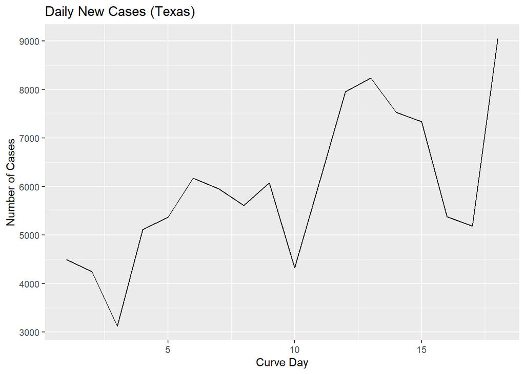

```r
ggplot(data=df_tx, aes(x = Curve_Day, y = Daily_New_Cases)) +
      geom_line() +
      ggtitle("Daily New Cases (Texas)") +
      labs(x = "Curve Day", y = "Number of Cases")
```

```r
summary(df_tx)
```

```
##     State               Date           Daily_New_Cases   Curve_Day
##  Length:18          Length:18          Min.   :3125    Min.   : 1.00
##  Class :character   Class :character   1st Qu.:5130    1st Qu.: 5.25
##  Mode  :character   Mode  :character   Median :5787    Median : 9.50
##                                        Mean   :5964    Mean   : 9.50
##                                        3rd Qu.:7052    3rd Qu.:13.75
##                                        Max.   :9054    Max.   :18.00
##     Pop_Pct
##  Min.   :0.0001045
##  1st Qu.:0.0001716
##  Median :0.0001935
##  Mean   :0.0001994
##  3rd Qu.:0.0002358
##  Max.   :0.0003028
```

Log the population percentage variable to address the stationarity assumption.

```r
df_tx$Pop_Pct_Log <- log(df_tx$Pop_Pct)
test$Pop_Pct_Log <- log(test$Pop_Pct)

train <- df_tx
```

# Time Series

As the information from the New York and New Jersey data sets would not make sense to include in a basic arima model, it has been excluded for now.

```r
tsdata1 <- ts(train$Pop_Pct_Log, frequency = 365)

tsdata2 <- ts(test$Pop_Pct_Log, frequency = 365 , start = c(1, 19))
```

## Time Series 1

The original Texas data from June 19th, 2020 to July 6th, 2020.

```r
tsdata1
```

```
## Time Series:
## Start = c(1, 1)
## End = c(1, 18)
## Frequency = 365
##  [1] -8.802212 -8.858980 -9.166323 -8.673847 -8.624778 -8.484726 -8.520699
##  [8] -8.580133 -8.500828 -8.840157 -8.491525 -8.231263 -8.196560 -8.286081
## [15] -8.311806 -8.622554 -8.660486 -8.102438
```

## Time Series 2

The actual Texas data from July 7th, 2020 to August 7th, 2020.

```r
tsdata2
```

```
## Time Series:
## Start = c(1, 19)
## End = c(1, 50)
## Frequency = 365
##  [1] -8.020378 -7.940148 -7.828991 -7.949109 -8.145284 -8.455114 -8.058859
##  [8] -7.862050 -7.780685 -7.979019 -8.054743 -8.233071 -8.141257 -8.235591
## [15] -7.970465 -7.951575 -8.064691 -8.159449 -8.259858 -8.844908 -8.483163
## [22] -7.904360 -8.084564 -8.125988 -8.028346 -8.400526 -8.668172 -8.360132
## [29] -7.888808 -8.041250 -8.273526 -8.267645
```

```r
# store the estimates in a list to be used later
logged_estimates <- tsdata2[1:32]
```

## ARIMA Model

- AR = 7
- MA = 7

The ARIMA model seemed to outperform the AUTO-ARIMA one in the ability to pick up the cyclical trends in the data.

```r
# autoarima1 <- auto.arima(tsdata1)

arima1 <- arima(tsdata1, order=c(7, 1, 7))
```

```r
# auto-arima
# forcast1 <- forecast(autoarima1, h=32)

# ar 1
forcast1 <- forecast(arima1, h=32)
```

## Plot the Forcast

You can see that as there’s nothing in the training data to indicate that the slope will flatten or turn negative, we need some way of “bending” the curve to reflect the trends seen already in the other states.

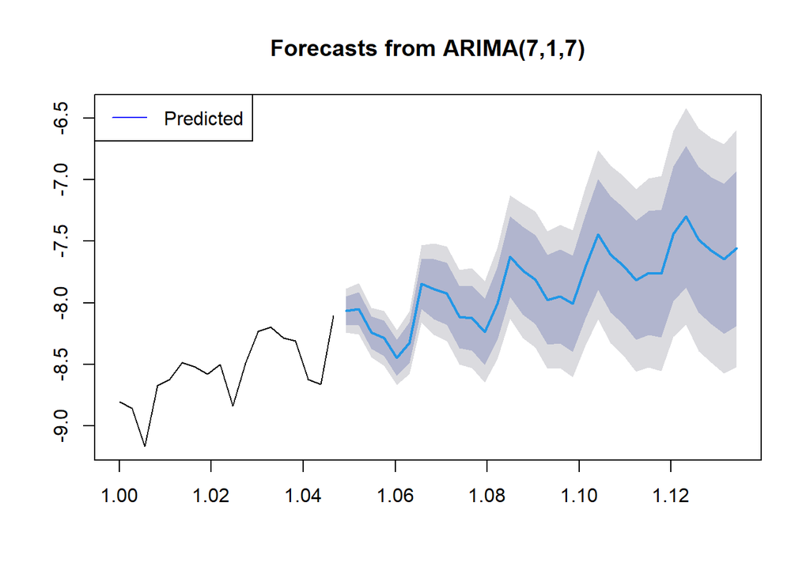

```r
plot(forcast1)
legend(x = "topleft", legend = c("Predicted"), col = c("blue"), lty = c(1, 1))
```

## Dampening Technique

Visually inspecting the New york and New Jersey plots, you can see that at around day 30 each the graphs seemed to hit an inflection point.

In an attempt to bend the curve downwards, we will gradually reduce the counts over what our predictions from the arima model produced from this same point in the Texas data.

The adjustment starting point was 1/10th of the standard deviation from the logged estimates, which increases by 0.0025 for each iteration of the loop.

```r
# adjust by 1/10th of the standard deviation from the logged estimates
dampen = sd(logged_estimates) / 10  # 0.02425344

# day 31
# forcast1$mean[13:32] <- forcast1$mean[13:32] - (-forcast1$mean[13:32] * dampen)

for (i in 13:32) {
  # print(forcast1$mean[[i]])
  # print(i)
  forcast1$mean[i] <- forcast1$mean[i] - (-forcast1$mean[i] * dampen)
  dampen =  dampen + 0.0025
}

# forcast1$mean

# sd(logged_estimates) / 10
```

## Predictions

As the predictions were based off the logged population percentage variable, we need to exponentiate it and then multiply by the Texas Population to get it back to a daily count.

```r
y_hat <- round(exp(forcast1$mean) * texas_population)
y_hat
```

```
## Time Series:
## Start = c(1, 19)
## End = c(1, 50)
## Frequency = 365
##  [1]  9406  9556  7886  7534  6428  7258 11712 11215 10812  8934  8854  7916
## [13]  8215 11883 10385  9452  7820  7891  7286  9739 12561 10395  9291  8030
## [25]  8399  8197 11312 12903 10330  9248  8448  9101
```

## Plot the Predicted and Actual Results

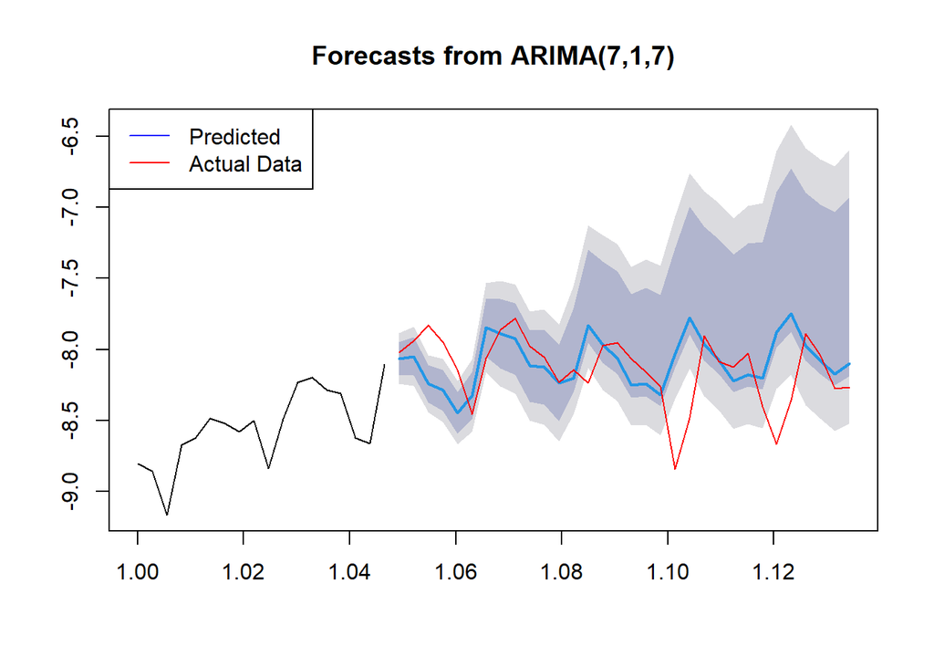

```r
plot(forcast1)
lines(tsdata2, col="red")
legend(x = "topleft", legend = c("Predicted", "Actual Data"), col = c("blue", "red"), lty = c(1, 1))
```

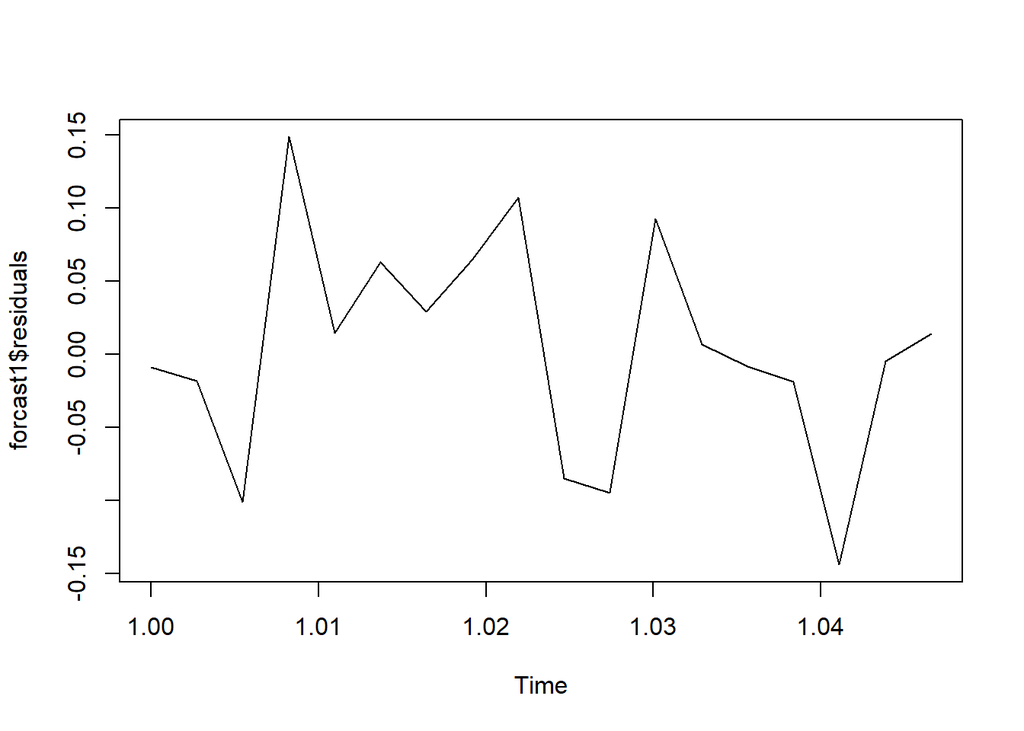

```r
plot(forcast1$residuals)
```

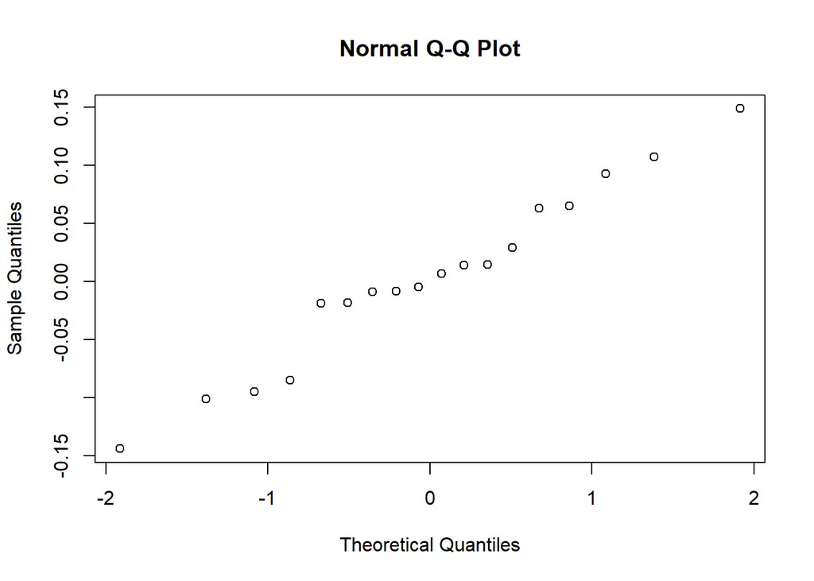

```r
qqnorm(forcast1$residuals)
```

## Analyze ACF/ PACF Plots

### ACF

The ACF plot gradually tapers off at the end

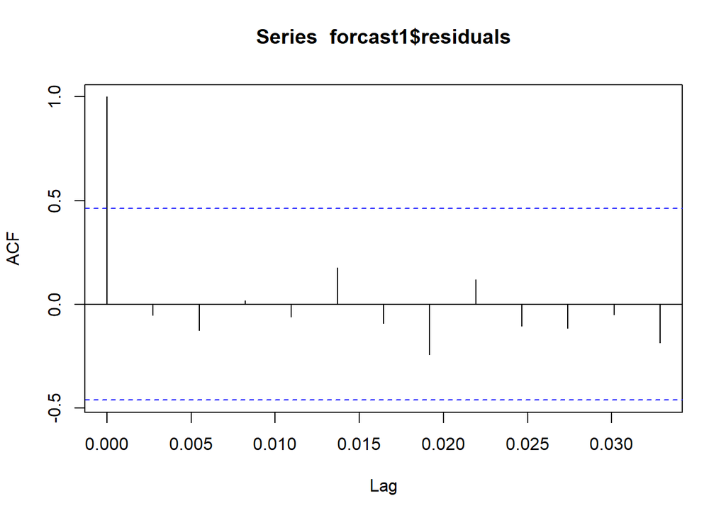

```r
acf(forcast1$residuals)
```

### PACF

The PACF plot also gradually tapers off at the end indicating a probable ARMA combination.

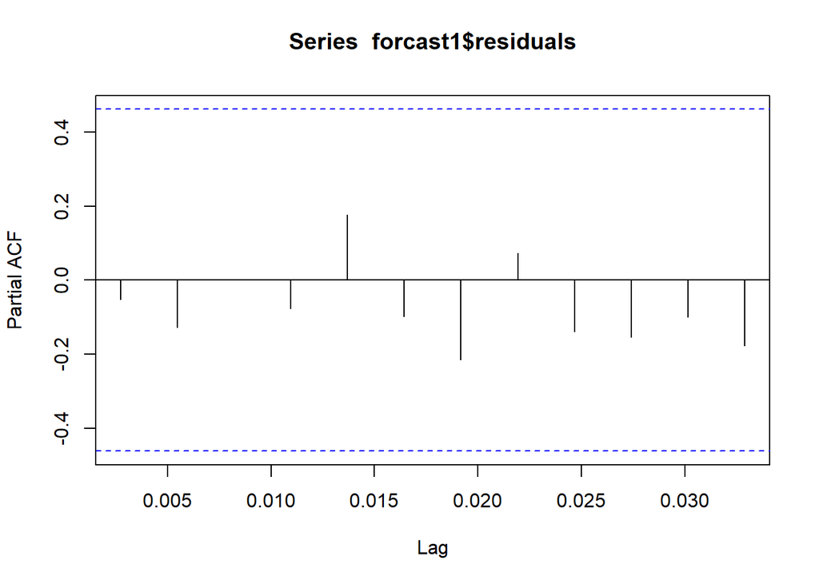

```r
pacf(forcast1$residuals)
```

# Predictions

## Mean Absolute Error

The final MAE score was 1809.844, which is the average error rate after negating the sign for all 32 predictions.

```r
# summary(arima1)
# accuracy(arima1)

MAE(y_pred = (round(exp(forcast1$mean) * texas_population)), y_true = test$Daily_New_Cases)
```

```
## [1] 1809.844
```

```r
Predictions <- y_hat[1:32]

df_out <- cbind(data2, Predictions)
```

## Daily New Case Prediction Line Chart

```r
df_1 <- df_tx %>%
   # mutate(Type = 'Actual') %>%
   select(Date, Curve_Day, Daily_New_Cases)

df_2 <- df_out %>%
   # mutate(Type = 'Actual') %>%
   select(TX.Date, Curve_Day, TX.New.Cases)


df_3 <- df_out %>%
   # mutate(Type = 'Predicted') %>%
   select(TX.Date, Curve_Day, Predictions)


df_1 <- plyr::rename(df_1, replace = c("Daily_New_Cases"="New_Cases"))
df_2 <- plyr::rename(df_2, replace = c("TX.Date"="Date", "TX.New.Cases"="New_Cases"))
df_3 <- plyr::rename(df_3, replace = c("TX.Date"="Date", "Predictions"="New_Cases"))


df_X <- df_2 %>%
  mutate(Type = 'Actual') %>%
  bind_rows(df_3 %>%
    mutate(Type = 'Predicted'))

df_X <- df_X %>%
  bind_rows(df_1 %>%
    mutate(Type = 'Train'))
```

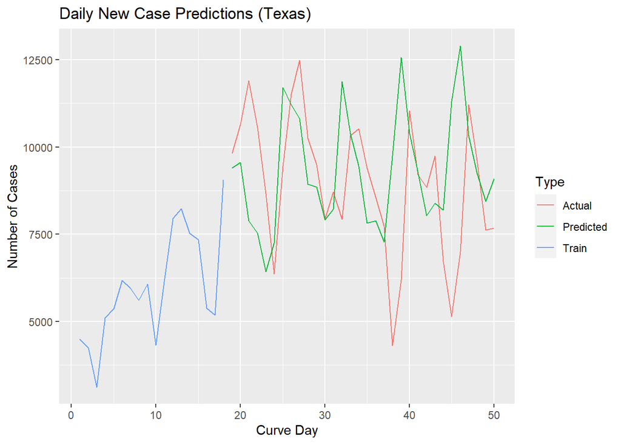

```r
ggplot(df_X,aes(y = New_Cases, x = Curve_Day, color = Type)) +
  geom_line() +
  ggtitle("Daily New Case Predictions (Texas)") +
  labs(x = "Curve Day", y = "Number of Cases")
```

## Final Output

The original `Corona_MAE.csv` validation set combined with the predictions and absolute difference.

```r
df_out <- df_out %>%
  mutate(Absolute.Difference = abs(TX.New.Cases - Predictions))

df_out
```

```
##      TX.Date Curve_Day TX.New.Cases Predictions Absolute.Difference
## 1   7/7/2020        19         9828        9406                 422
## 2   7/8/2020        20        10649        9556                1093
## 3   7/9/2020        21        11901        7886                4015
## 4  7/10/2020        22        10554        7534                3020
## 5  7/11/2020        23         8674        6428                2246
## 6  7/12/2020        24         6363        7258                 895
## 7  7/13/2020        25         9457       11712                2255
## 8  7/14/2020        26        11514       11215                 299
## 9  7/15/2020        27        12490       10812                1678
## 10 7/16/2020        28        10243        8934                1309
## 11 7/17/2020        29         9496        8854                 642
## 12 7/18/2020        30         7945        7916                  29
## 13 7/19/2020        31         8709        8215                 494
## 14 7/20/2020        32         7925       11883                3958
```

[output cut: 18 more lines]

```r
# write.csv(df_out,"./Corona_MAE.csv", row.names = FALSE)
```